# NYPD Shooting Incidents

Artur Ayzenberg

2025-03-30

## Step 1 importing the NYPD shooting data

```r
library(tidyverse)
```

```r
library(lubridate)
library(ggplot2)
url_in <- "https://data.cityofnewyork.us/api/views/833y-fsy8/rows.csv?accessType=DOWNLOAD"
nypd_shooting <- read.csv(url_in)
```

## Step 2 tidy the data

In the below step NYPD shooting data is collected. Next the data is further assigned to variables for step 3 visualization and analysis. One such point will be the year_frequency variable to determine if shootings are on the decline or on the rise. Next 2 separate variables are collected, age breakdown of perpetrators and victims.

```r
nypd_shooting <- nypd_shooting %>% select(-c(X_COORD_CD, Y_COORD_CD, Latitude, Longitude, Lon_Lat))
nypd_shooting <- nypd_shooting %>% mutate(OCCUR_DATE = mdy(OCCUR_DATE))
summary(nypd_shooting)
```

```
##   INCIDENT_KEY         OCCUR_DATE          OCCUR_TIME            BORO
##  Min.   :  9953245   Min.   :2006-01-01   Length:29744       Length:29744
##  1st Qu.: 67321140   1st Qu.:2009-10-29   Class :character   Class :character
##  Median :109291972   Median :2014-03-25   Mode  :character   Mode  :character
##  Mean   :133850951   Mean   :2014-10-31
##  3rd Qu.:214741917   3rd Qu.:2020-06-29
##  Max.   :299462478   Max.   :2024-12-31
##
##  LOC_OF_OCCUR_DESC     PRECINCT      JURISDICTION_CODE LOC_CLASSFCTN_DESC
##  Length:29744       Min.   :  1.00   Min.   :0.0000    Length:29744
##  Class :character   1st Qu.: 44.00   1st Qu.:0.0000    Class :character
##  Mode  :character   Median : 67.00   Median :0.0000    Mode  :character
##                     Mean   : 65.23   Mean   :0.3181
##                     3rd Qu.: 81.00   3rd Qu.:0.0000
##                     Max.   :123.00   Max.   :2.0000
##                                      NA's   :2
##  LOCATION_DESC      STATISTICAL_MURDER_FLAG PERP_AGE_GROUP
##  Length:29744       Length:29744            Length:29744
##  Class :character   Class :character        Class :character
##  Mode  :character   Mode  :character        Mode  :character
##
##
##
##
##    PERP_SEX          PERP_RACE         VIC_AGE_GROUP        VIC_SEX
##  Length:29744       Length:29744       Length:29744       Length:29744
##  Class :character   Class :character   Class :character   Class :character
##  Mode  :character   Mode  :character   Mode  :character   Mode  :character
##
##
##
##
##    VIC_RACE
##  Length:29744
##  Class :character
##  Mode  :character
##
##
##
##
```

```r
##### Isolate the yearly occurrences #####
yearly_totals <- format(as.Date(nypd_shooting$OCCUR_DATE, format="%Y/%m/%d"),"%Y")
yearly_totals <- table(yearly_totals)
year_frequency <- as.data.frame.table(yearly_totals)
year_frequency$yearly_totals <- as.numeric(as.character(year_frequency$yearly_totals))

##### Victims and Perpetrators by age #####
# Perp ages
ages_of_perp <- nypd_shooting %>% select(c(PERP_AGE_GROUP))
ages_of_perp <- as.data.frame.table(ages_of_perp)
ages_of_perp <- ages_of_perp[!(ages_of_perp$PERP_AGE_GROUP %in% "UNKNOWN"),]
ages_of_perp <- ages_of_perp[!(ages_of_perp$PERP_AGE_GROUP %in% "(null)"),]
ages_of_perp <- ages_of_perp[!(ages_of_perp$PERP_AGE_GROUP == ""),]
table(ages_of_perp$PERP_AGE_GROUP) # Step is done to determine any ages/age groups that din't make sense to remove them for data cleanliness
```

```
##
##   <18  1020  1028 18-24  2021   224 25-44 45-64   65+   940
##  1805     1     1  6630     1     1  6342   775    67     1
```

```r
ages_of_perp <- ages_of_perp[!(ages_of_perp$PERP_AGE_GROUP == "1020"),]
ages_of_perp <- ages_of_perp[!(ages_of_perp$PERP_AGE_GROUP == "1028"),]
ages_of_perp <- ages_of_perp[!(ages_of_perp$PERP_AGE_GROUP == "224"),]
ages_of_perp <- ages_of_perp[!(ages_of_perp$PERP_AGE_GROUP == "940"),]
ages_of_perp <- ages_of_perp[!(ages_of_perp$PERP_AGE_GROUP == "2021"),]
ages_of_perp <- ages_of_perp[c("PERP_AGE_GROUP")]
ages_of_perp <- table(ages_of_perp)
ages_of_perp_groups <- as.data.frame.table(ages_of_perp)
# Victim ages
ages_of_vic <- nypd_shooting %>% select(c(VIC_AGE_GROUP))
ages_of_vic <- as.data.frame.table(ages_of_vic)
ages_of_vic <- ages_of_vic[!(ages_of_vic$VIC_AGE_GROUP %in% "UNKNOWN"),]
ages_of_vic <- ages_of_vic[!(ages_of_vic$VIC_AGE_GROUP %in% "(null)"),]
ages_of_vic <- ages_of_vic[!(ages_of_vic$VIC_AGE_GROUP == ""),]
table(ages_of_vic$VIC_AGE_GROUP) # Step is done to determine any ages/age groups that din't make sense to remove them for data cleanliness
```

```
##
##   <18  1022 18-24 25-44 45-64   65+
##  3081     1 10677 13563  2118   236
```

```r
ages_of_vic <- ages_of_vic[!(ages_of_vic$VIC_AGE_GROUP == "1022"),]
ages_of_vic <- ages_of_vic[c("VIC_AGE_GROUP")]
ages_of_vic <- table(ages_of_vic)
ages_of_vic_groups <- as.data.frame.table(ages_of_vic)
```

## Step 3 Visualize the data

Based on the variable above data visualization will be presented as well as some respective analysis. Analysis will be based on R calculations or other possible tests

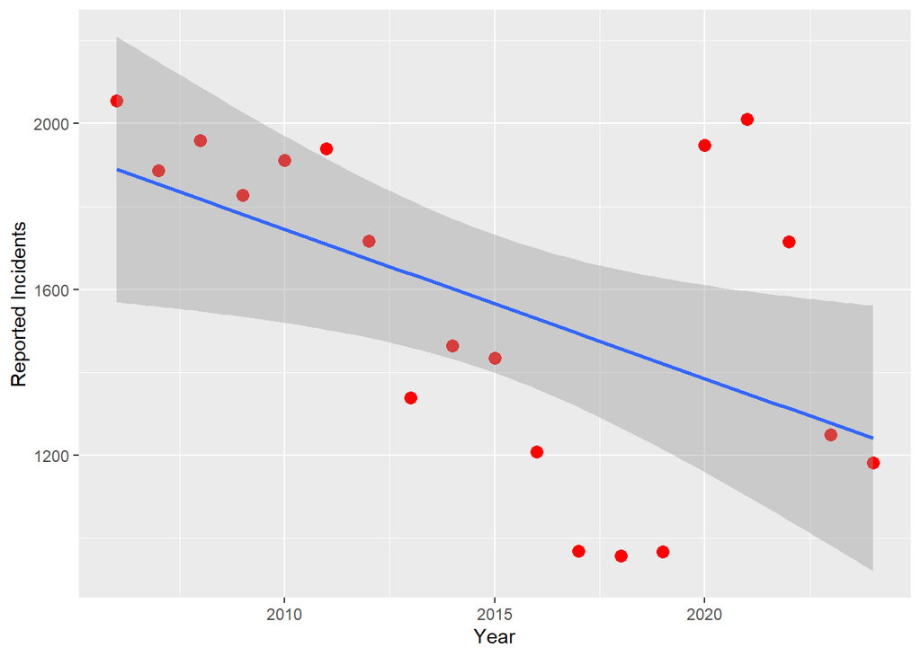

```r
#Frequency visualization
ggplot(year_frequency, aes(x = yearly_totals, y = Freq)) + labs(x="Year", y="Reported Incidents") + geom_point(size = 3, color = 'red') + geom_smooth(method=lm)
```

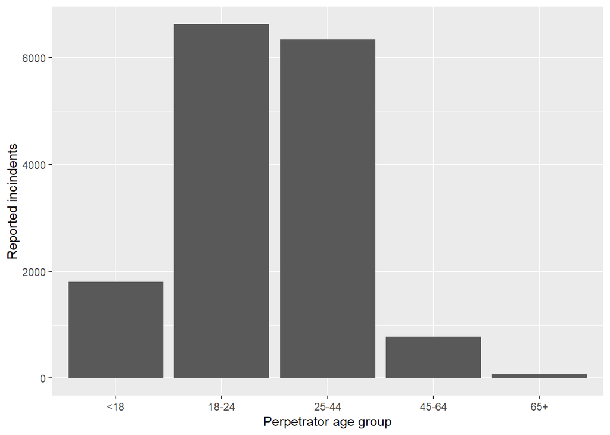

```r
#Perpetrator ages
ggplot(ages_of_perp_groups, aes(x=PERP_AGE_GROUP, y=Freq)) + labs(x="Perpetrator age group", y="Reported incindents") + geom_bar(stat="identity")
```

```r
sum(ages_of_perp_groups$Freq)
```

```
## [1] 15619
```

```r
ages_of_perp_groups
```

| PERP_AGE_GROUP | Freq |
| --- | --- |
| <18 | 1805 |
| 18-24 | 6630 |
| 25-44 | 6342 |
| 45-64 | 775 |
| 65+ | 67 |

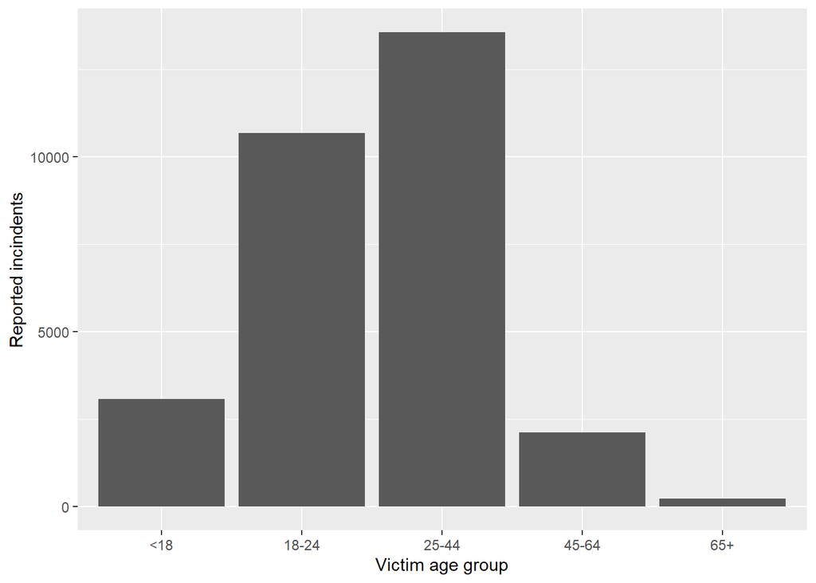

```r
#Victim ages
ggplot(ages_of_vic_groups, aes(x=VIC_AGE_GROUP, y=Freq)) + labs(x="Victim age group", y="Reported incindents") + geom_bar(stat="identity")
```

```r
sum(ages_of_vic_groups$Freq)
```

```
## [1] 29675
```

```r
ages_of_vic_groups
```

| VIC_AGE_GROUP | Freq |
| --- | --- |
| <18 | 3081 |
| 18-24 | 10677 |
| 25-44 | 13563 |
| 45-64 | 2118 |
| 65+ | 236 |

## Step 3 Analyze the data

The following includes the analysis for items visualized above.

```r
#Frequency analysis
year_model <- lm(year_frequency$Freq ~ year_frequency$yearly_totals, data = year_frequency)
summary(year_model)
```

```
##
## Call:
## lm(formula = year_frequency$Freq ~ year_frequency$yearly_totals,
##     data = year_frequency)
##
## Residuals:
##     Min      1Q  Median      3Q     Max
## -523.42 -218.01   33.32  165.84  661.68
##
## Coefficients:
##                              Estimate Std. Error t value Pr(>|t|)
## (Intercept)                  74158.50   29035.88   2.554   0.0205 *
## year_frequency$yearly_totals   -36.03      14.41  -2.500   0.0229 *
## ---
## Signif. codes:  0 '***' 0.001 '**' 0.01 '*' 0.05 '.' 0.1 ' ' 1
##
## Residual standard error: 344 on 17 degrees of freedom
## Multiple R-squared:  0.2688, Adjusted R-squared:  0.2258
## F-statistic: 6.251 on 1 and 17 DF,  p-value: 0.02294
```

```r
#Perpetrator ages
ratio_perp <- 1682/sum(ages_of_perp_groups$Freq)
ratio_victim <- 2954/sum(ages_of_vic_groups$Freq)
std_err <- sqrt(((ratio_perp * (1 - ratio_perp)) / sum(ages_of_perp_groups$Freq)) + ((ratio_victim * (1 - ratio_victim)) / sum(ages_of_vic_groups$Freq)))
z_score <- (ratio_perp - ratio_victim) / std_err
p_value <- pnorm(q=z_score, lower.tail=FALSE)
ratio_perp
```

```
## [1] 0.1076894
```

```r
ratio_victim
```

```
## [1] 0.09954507
```

```r
std_err
```

```
## [1] 0.003028673
```

```r
z_score
```

```
## [1] 2.68906
```

```r
p_value
```

```
## [1] 0.003582682
```